# Simulation Results

### Summary

Wins

%

Average  
Ladder

Premiers

Minor  
Premiers

Top 4

Top 8

Wooden  
Spoon

1

[figure not shown]

Western Bulldogs

17.2

145.0

1.9

31.4

49.8

95.4

100.0

0.0

2

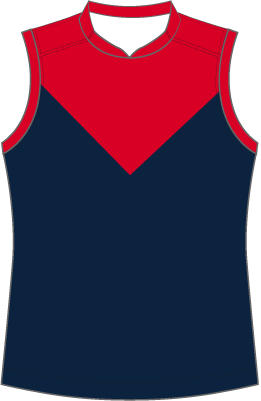

Melbourne

16.7

125.4

2.9

17.3

25.2

83.4

99.8

0.0

3

[figure not shown]

Geelong

16.0

125.6

3.3

15.9

13.5

77.9

99.4

0.0

4

[figure not shown]

Brisbane

15.6

130.1

3.5

16.3

8.3

76.4

99.3

0.0

5

[figure not shown]

Port Adelaide

14.6

119.0

4.8

8.1

3.1

43.9

96.2

0.0

6

[figure not shown]

Richmond

12.7

109.8

7.0

4.7

0.0

9.2

78.3

0.0

7

[figure not shown]

West Coast

12.5

105.1

7.4

2.2

0.1

7.0

71.6

0.0

8

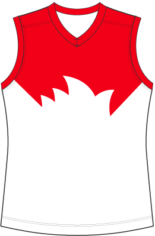

Sydney

12.3

103.3

7.8

1.3

0.0

5.0

64.9

0.0

9

[figure not shown]

Essendon

10.7

102.5

9.6

1.3

0.0

0.7

33.8

0.0

10

[figure not shown]

Greater Western Sydney

10.5

96.1

10.0

0.7

0.0

1.0

28.0

0.0

11

[figure not shown]

Fremantle

9.7

91.1

11.4

0.3

0.0

0.2

13.9

0.0

12

[figure not shown]

Carlton

8.7

94.7

12.5

0.2

0.0

0.0

5.5

0.5

13

[figure not shown]

Adelaide

8.5

86.9

13.2

0.1

0.0

0.0

2.7

0.6

14

[figure not shown]

Collingwood

8.1

91.9

13.2

0.2

0.0

0.0

4.0

0.6

15

[figure not shown]

St Kilda

8.0

79.8

14.0

0.0

0.0

0.0

1.8

0.5

16

[figure not shown]

Gold Coast

7.1

85.0

14.7

0.0

0.0

0.0

1.0

3.1

17

[figure not shown]

Hawthorn

5.9

80.0

16.0

0.0

0.0

0.0

0.1

9.7

18

[figure not shown]

North Melbourne

3.4

64.3

17.8

0.0

0.0

0.0

0.0

84.9

### Ladder Distribution

T8

1

2

3

4

5

6

7

8

9

10

11

12

13

14

15

16

17

18

1

[figure not shown]

Western Bulldogs

100.0

49.8

25.2

13.6

6.7

3.1

1.1

0.4

0.1

0.0

0.0

0.0

0.0

0.0

0.0

0.0

0.0

0.0

0.0

2

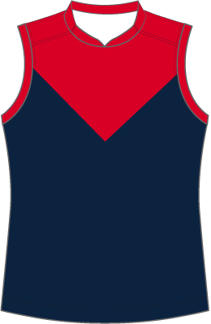

Melbourne

99.8

25.2

22.5

21.0

14.8

10.1

4.0

1.7

0.6

0.2

0.0

0.0

0.0

0.0

0.0

0.0

0.0

0.0

0.0

3

[figure not shown]

Geelong

99.4

13.5

22.7

21.6

20.1

12.5

5.5

2.5

1.0

0.4

0.2

0.0

0.0

0.0

0.0

0.0

0.0

0.0

0.0

4

[figure not shown]

Brisbane

99.3

8.3

21.0

25.3

21.8

12.7

6.1

2.8

1.2

0.4

0.2

0.1

0.0

0.0

0.0

0.0

0.0

0.0

0.0

5

[figure not shown]

Port Adelaide

96.2

3.1

7.3

12.9

20.7

25.4

14.2

8.4

4.4

2.1

1.0

0.5

0.1

0.1

0.0

0.0

0.0

0.0

0.0

6

[figure not shown]

Richmond

78.3

0.0

0.5

2.3

6.4

12.9

21.1

20.3

14.7

9.4

5.6

3.4

1.8

0.9

0.4

0.2

0.0

0.0

0.0